# Assignment 3: bikes, EDA and predictive modeling

[Captial Bikeshare](https://www.capitalbikeshare.com/) releases a large amount of their data to the public about bike rentals in Washinton, DC. For example they released a data set with the hourly count of bike rentals in 2011 and 2012 with correspoonding weather/seasonal covariates on the famous [UCI Machine Learning Repository](https://archive.ics.uci.edu/ml/datasets/Bike+Sharing+Dataset).

In this assigment you will first do an exploratory analysis of the 2011 data. You will then build a model to predict rental counts for the 2012 data.

Assignment 3 is due **Tuesday March 7th**. There are three deliverables: 2 .Rmd files and one .csv file. Some examples are given below.

# Part 1: exploratory analysis

Make 10 exploratory figures and include a brief discussion of each figure.

- A figure can be a plot, the output of a linear regression, or a non-trivial piece of code you write (e.g. a t-test).
- Most of the figures should be plots.
- The figures should be fairly different. For example, a faceted plot only counts as one figure.
- The axes should be labels and there should be a legend (if applicable).

The figure discussion should include:

- Short description of the figure and the takeaway(s).
- Some details supporting/qualifying the takeaway(s).

The deliverable for this part is a .Rmd file with the plots and a discussion.

# Part 2: predictive modeling

Based on the bike sharing data from 2011 write a model that predicts the ride counts for each hour in 2012. Try at least 2 “different” models and compare them using a test set. You have the full data from 2011 and all the x data from 2012 (see below).

There are two deliverable for this part

- a .Rmd file with the code and a brief discussion
- a .csv with your predictions named `bike_predictions_2012_ONYEN.csv`

For the .Rmd file you should include the code for training each model and comparing each model. You should also include a brief discussion describing each model.

The predictions .csv should be the original 2012 file with a new column added called `cnt_pred`. Use the `write_csv` function to write the .csv.

For this task you should first split the 2011 data into a `train` and `test` set. First train each of your models on the `train` set then compare them using the `test` set.

What constitutes “different”" models is a little subjective. We count linear regression with different enough features as different models. Different variable selection procedures also count as different models. You cannot use exactly the same model we used in class without some modificaiton.

At least one of the models you fit should involve a data driven tuning procedure with a validation set for example,

- the procedure to select the degree of the polynomial from the first [predictive modeling lecture](https://idc9.github.io/stor390/notes/predictive_modeling/predictive_modeling.html)
- cross-validation to select the best tuning parameter value for L1 or L2 regularize linear regression

The validation set should be a subset of the `train` data, **not** the test set you made. Only use the test set to compare your (2 or more) “final” models.

**#winning** Whomever builds the best predictive model, as measured by mean squared error on the 2012 data, will recieve one extra credit point. Additionally, another extra credit point will be awarded to the best insight from the EDA. More extra credit points may be awarded for going above and beyond the assignment requirments.

# Hints

1. Make a train/test set
2. Train two models on the training set
3. Compare your models on the test set
4. Make predictions for 2012 on the full 2011 data set with the model you selected

Read in the data with

```r
library(tidyverse)

# data from 2011
hour11 <- read_csv('https://raw.githubusercontent.com/idc9/stor390/master/data/bikes_2011.csv')

# x data from 2012
hour12_x <- read_csv('https://raw.githubusercontent.com/idc9/stor390/master/data/bikes_12_x.csv')

# set categorical variables to factors
hour11 <- hour11 %>%
            mutate(workingday=factor(workingday),
                   weathersit=factor(weathersit),
                   weekday=factor(weekday))

# set categorical variables to factors
hour12_x <- hour12_x %>%
            mutate(workingday=factor(workingday),
                   weathersit=factor(weathersit),
                   weekday=factor(weekday))
```

## EDA plot example

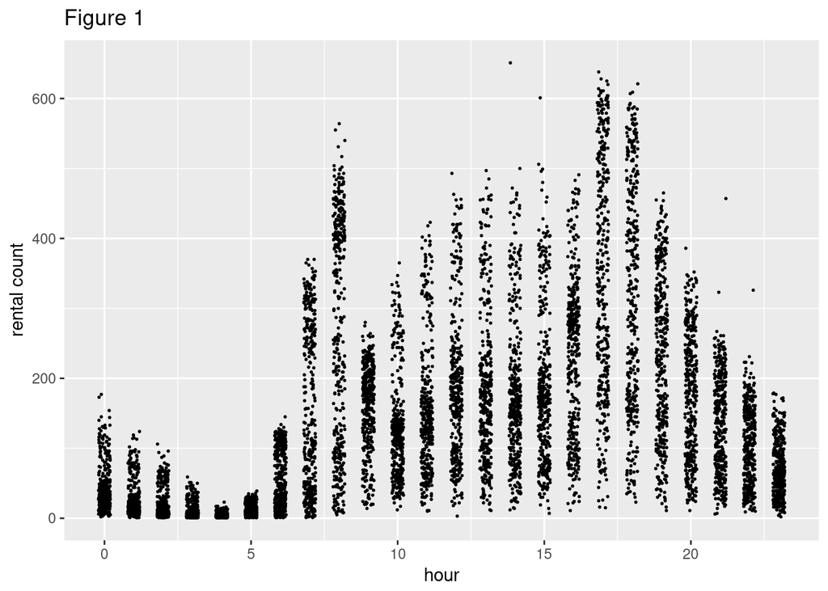

```r
hour11 %>%
    ggplot() +
    geom_jitter(aes(x=hr, y=cnt), width=.2, height=0, size=.3) +
    ggtitle('Figure 1') +
    labs(x = 'hour', y = 'rental count')
```

Figure 1 shows bike rental counts per hour for each hour in 2011. As might be expected the rental traffic is higher during the day than at night. There appear to be two traffic spikes: one in the morning (around 8am) and one in the evening (around 5pm). These spikes might suggest that people use Capital Bike rentals to get to and from work. Looking carefully at the morning spike ther appears to be two clusters: one with higher traffic, one with lower traffic. It could be worthwhile to determine what is driving this possible difference in bike rental behavior in the morning.

## Predictive model example

```r
# fit a linear regression of count vs. hour in 2011
lin_reg <- lm(cnt ~ hr, data=hour11)

# get predictions for 2012 data
pred_12 <- predict(lin_reg, newdata = hour12_x)

# add predictions to 2012 data frame
hour12_x <- hour12_x %>%
            mutate(cnt_pred=pred_12)

# save the predictions
write_csv(hour12_x, 'bike_predictions_2012_idcarm.csv')
```

```r
summary(hour11)
```

```
##     instant         dteday               season            yr
##  Min.   :   1   Min.   :2011-01-01   Min.   :1.000   Min.   :0
##  1st Qu.:2162   1st Qu.:2011-04-04   1st Qu.:2.000   1st Qu.:0
##  Median :4323   Median :2011-07-04   Median :3.000   Median :0
##  Mean   :4323   Mean   :2011-07-03   Mean   :2.514   Mean   :0
##  3rd Qu.:6484   3rd Qu.:2011-10-02   3rd Qu.:3.000   3rd Qu.:0
##  Max.   :8645   Max.   :2011-12-31   Max.   :4.000   Max.   :0
##
##       mnth              hr           holiday        weekday  workingday
##  Min.   : 1.000   Min.   : 0.00   Min.   :0.00000   0:1231   0:2734
##  1st Qu.: 4.000   1st Qu.: 6.00   1st Qu.:0.00000   1:1235   1:5911
##  Median : 7.000   Median :12.00   Median :0.00000   2:1222
##  Mean   : 6.574   Mean   :11.57   Mean   :0.02765   3:1229
##  3rd Qu.:10.000   3rd Qu.:18.00   3rd Qu.:0.00000   4:1225
##  Max.   :12.000   Max.   :23.00   Max.   :1.00000   5:1239
##                                                     6:1264
##  weathersit      temp            atemp             hum
##  1:5645     Min.   :0.0200   Min.   :0.0000   Min.   :0.0000
##  2:2218     1st Qu.:0.3200   1st Qu.:0.3182   1st Qu.:0.4900
##  3: 781     Median :0.5000   Median :0.4848   Median :0.6500
##  4:   1     Mean   :0.4891   Mean   :0.4690   Mean   :0.6434
##             3rd Qu.:0.6600   3rd Qu.:0.6212   3rd Qu.:0.8100
##             Max.   :0.9600   Max.   :1.0000   Max.   :1.0000
##
##    windspeed          casual        registered         cnt
##  Min.   :0.0000   Min.   :  0.0   Min.   :  0.0   Min.   :  1.0
##  1st Qu.:0.1045   1st Qu.:  3.0   1st Qu.: 26.0   1st Qu.: 31.0
##  Median :0.1940   Median : 14.0   Median : 90.0   Median :109.0
##  Mean   :0.1912   Mean   : 28.6   Mean   :115.2   Mean   :143.8
##  3rd Qu.:0.2836   3rd Qu.: 38.0   3rd Qu.:168.0   3rd Qu.:211.0
##  Max.   :0.8507   Max.   :272.0   Max.   :567.0   Max.   :651.0
##
```

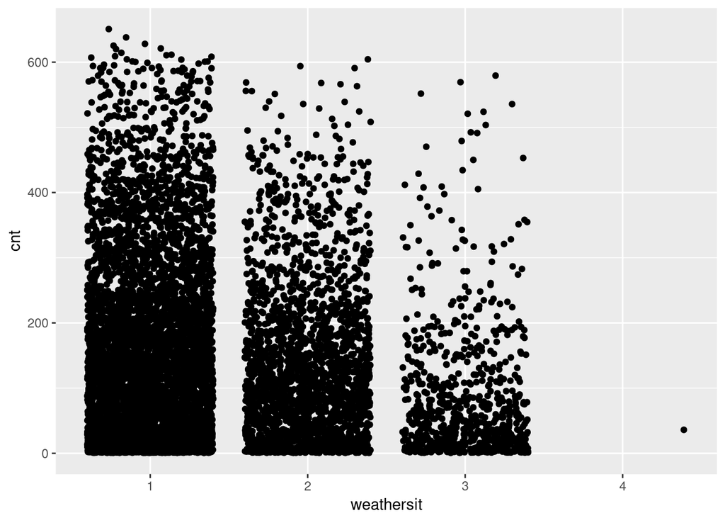

```r
# plot weather vs count
ggplot(hour11, mapping = aes(x = weathersit, y = cnt)) +
  geom_jitter()
```

As expected, as weather conditions worsen, ridership decreases.

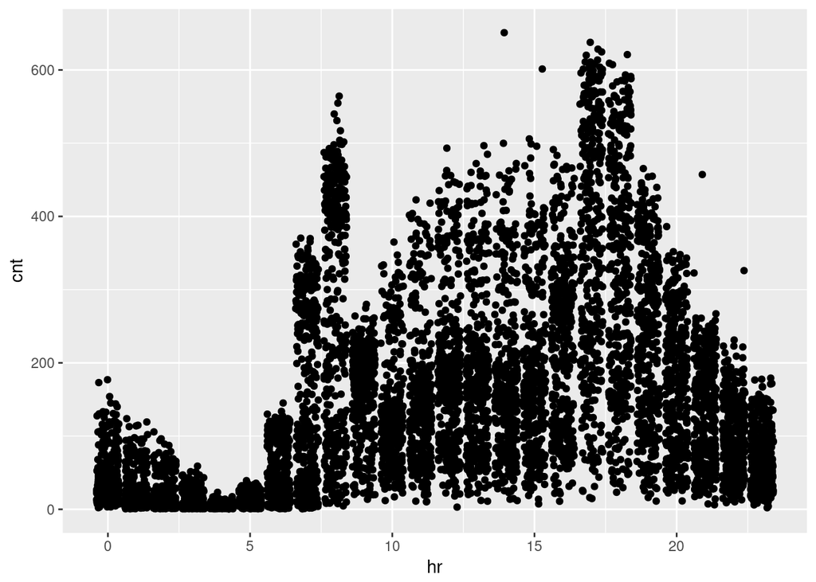

```r
# hour
ggplot(hour11, mapping = aes(x = hr, y = cnt)) +
  geom_jitter()
```

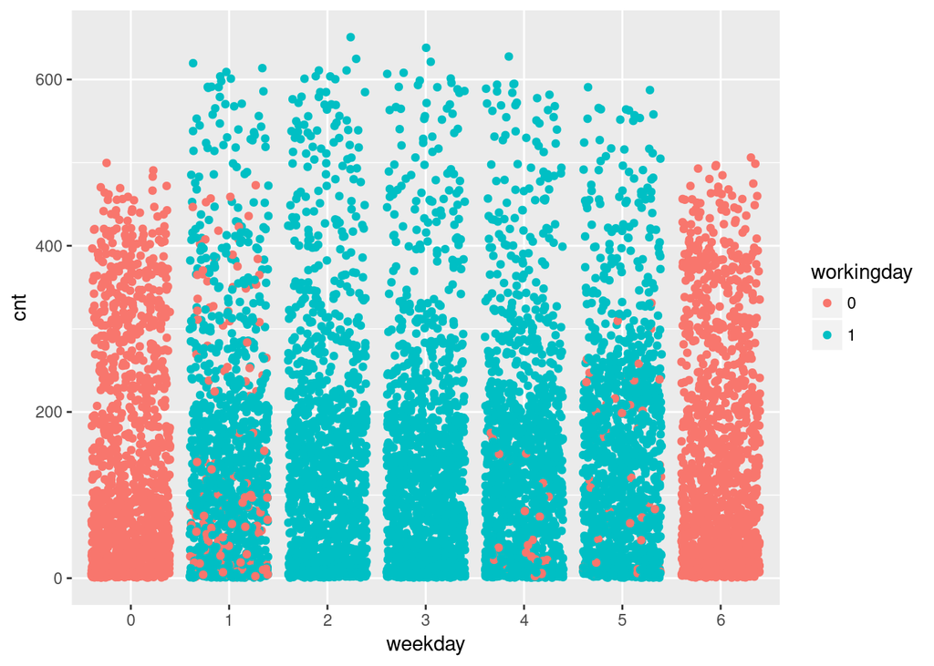

```r
# day
ggplot(hour11, mapping = aes(x = weekday, y = cnt, color = workingday)) +
  geom_jitter()
```

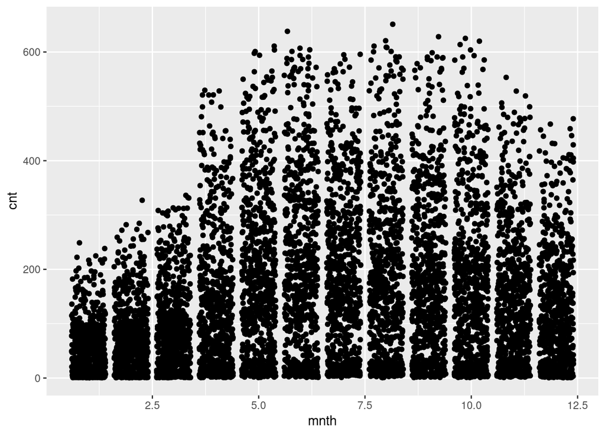

```r
# month
ggplot(hour11, mapping = aes(x = mnth, y = cnt)) +
  geom_jitter()
```

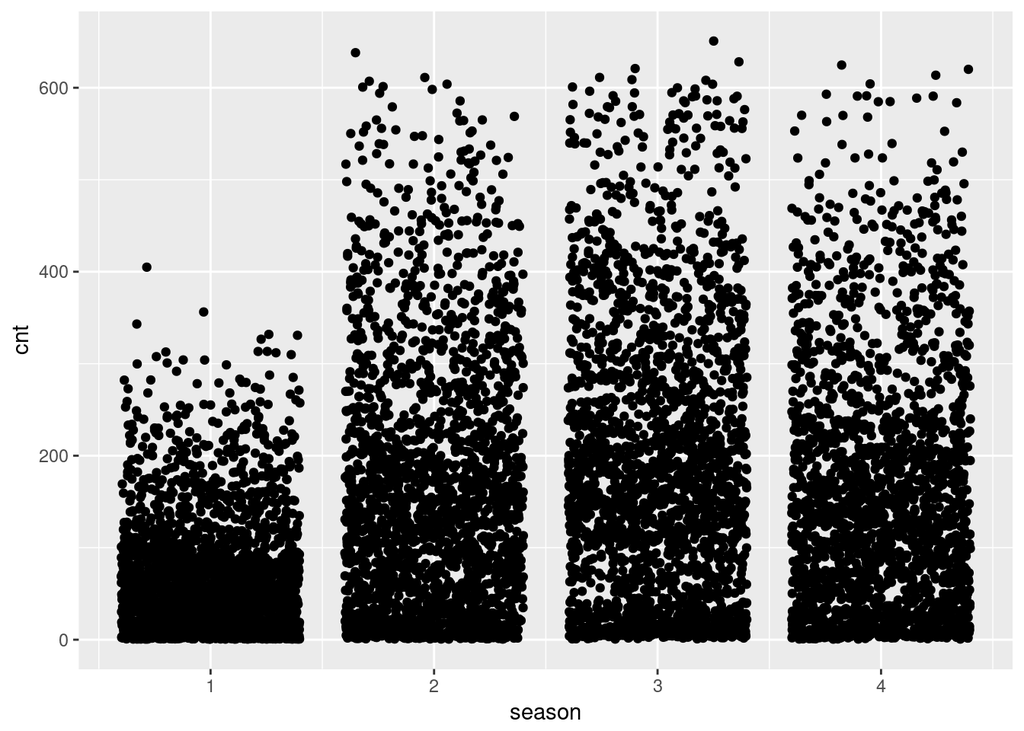

```r
# season, odd season defs
ggplot(hour11, mapping = aes(x = season, y = cnt)) +
  geom_jitter()
```

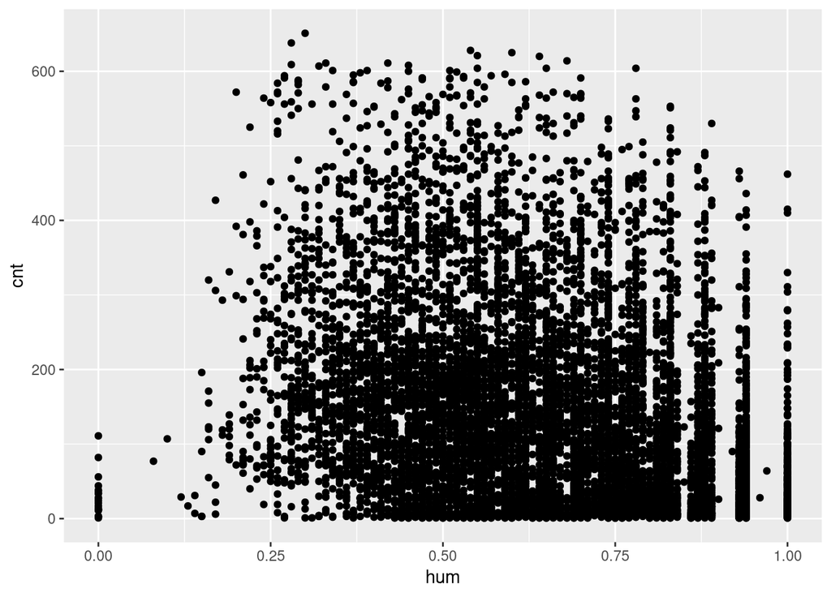

```r
# humidity
ggplot(hour11, mapping = aes(x = hum, y = cnt)) +
  geom_point()
```

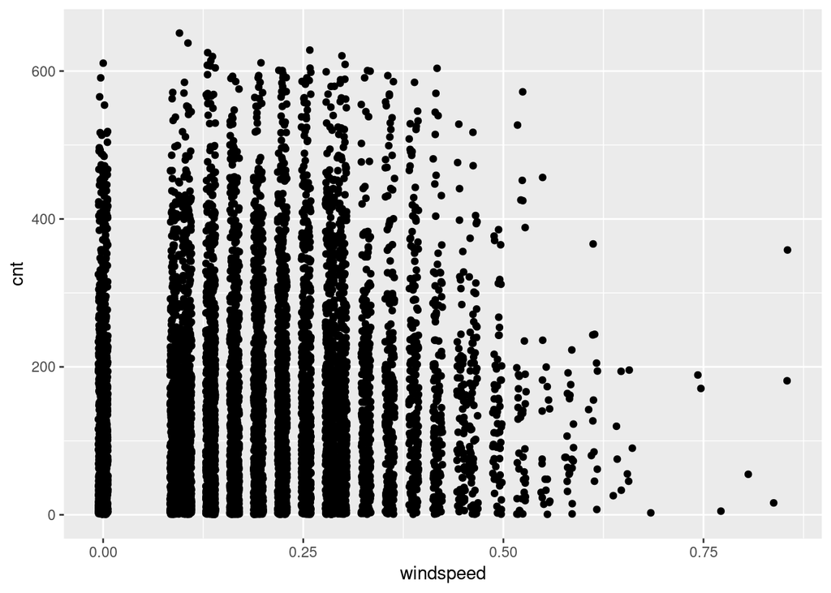

```r
# windspeed
ggplot(hour11, mapping = aes(x = windspeed, y = cnt)) +
  geom_jitter()
```

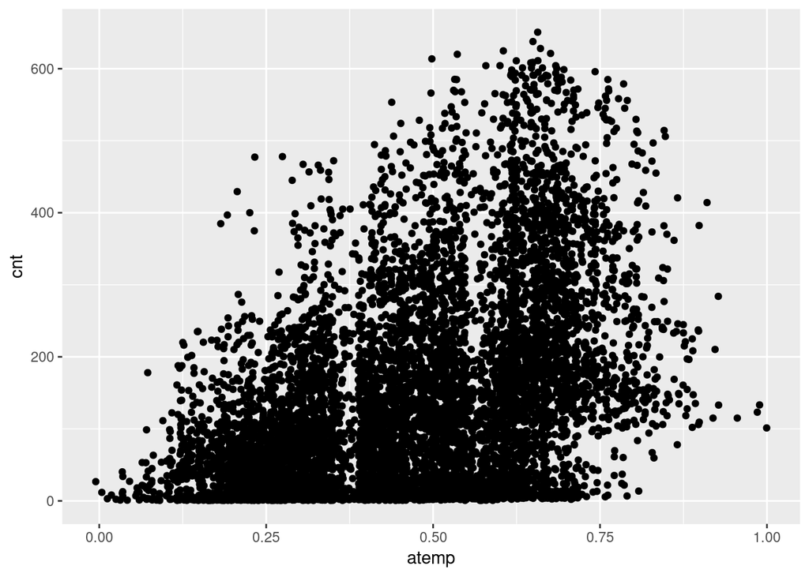

```r
# tmp
ggplot(hour11, mapping = aes(x = atemp, y = cnt)) +
  geom_jitter()
```

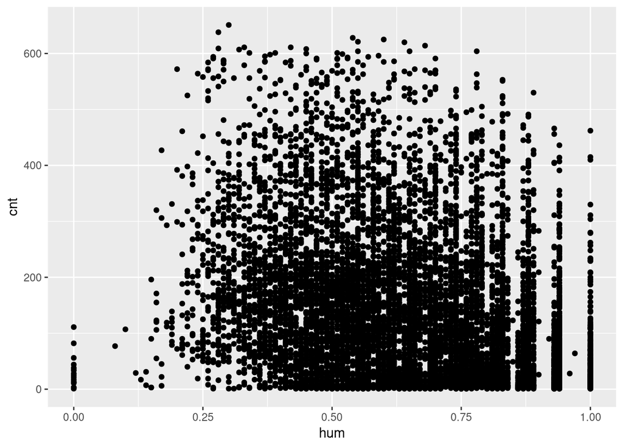

```r
# humidity
ggplot(hour11, mapping = aes(x = hum, y = cnt)) +
  geom_point()
```

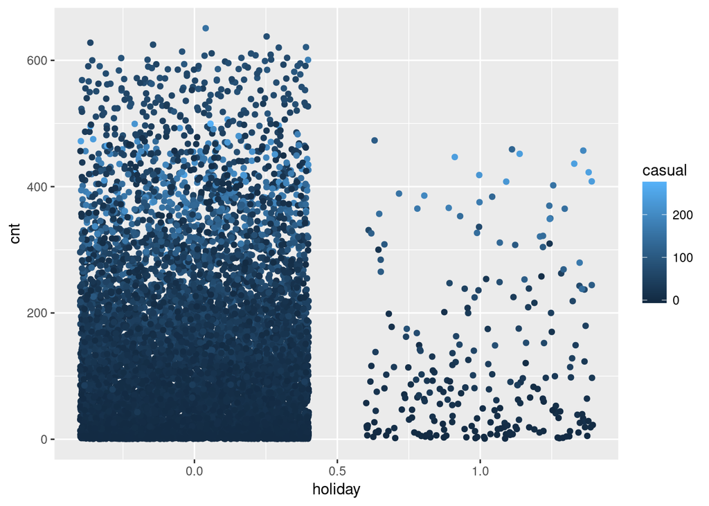

```r
# holiday vs ridership
ggplot(hour11, mapping = aes(x = holiday, y = cnt, color = casual)) +
  geom_jitter()
```